# Exploratory Analysis of Loan Data from Prosper

## Preliminary Wrangling

> This dataset includes more than 100,000 entries for loan borrowers with 81 attributes including loan amount, monthly income, loan status, delinquency and credit value

```python
# import all packages and set plots to be embedded inline
import numpy as np
import pandas as pd
import matplotlib.pyplot as plt
import seaborn as sb

%matplotlib inline
```

> Load in your dataset and describe its properties through the questions below. Try and motivate your exploration goals through this section.

```python
df = pd.read_csv('ProsperLoanData.csv')
```

```python
df.head()
```

|  | ListingKey | ListingNumber | ListingCreationDate | CreditGrade | Term | LoanStatus | ClosedDate | BorrowerAPR | BorrowerRate | LenderYield | ... | LP_ServiceFees | LP_CollectionFees | LP_GrossPrincipalLoss | LP_NetPrincipalLoss | LP_NonPrincipalRecoverypayments | PercentFunded | Recommendations | InvestmentFromFriendsCount | InvestmentFromFriendsAmount | Investors |
| --- | --- | --- | --- | --- | --- | --- | --- | --- | --- | --- | --- | --- | --- | --- | --- | --- | --- | --- | --- | --- | --- |
| 0 | 1021339766868145413AB3B | 193129 | 2007-08-26 19:09:29.263000000 | C | 36 | Completed | 2009-08-14 00:00:00 | 0.16516 | 0.1580 | 0.1380 | ... | -133.18 | 0.0 | 0.0 | 0.0 | 0.0 | 1.0 | 0 | 0 | 0.0 | 258 |
| 1 | 10273602499503308B223C1 | 1209647 | 2014-02-27 08:28:07.900000000 | NaN | 36 | Current | NaN | 0.12016 | 0.0920 | 0.0820 | ... | 0.00 | 0.0 | 0.0 | 0.0 | 0.0 | 1.0 | 0 | 0 | 0.0 | 1 |
| 2 | 0EE9337825851032864889A | 81716 | 2007-01-05 15:00:47.090000000 | HR | 36 | Completed | 2009-12-17 00:00:00 | 0.28269 | 0.2750 | 0.2400 | ... | -24.20 | 0.0 | 0.0 | 0.0 | 0.0 | 1.0 | 0 | 0 | 0.0 | 41 |
| 3 | 0EF5356002482715299901A | 658116 | 2012-10-22 11:02:35.010000000 | NaN | 36 | Current | NaN | 0.12528 | 0.0974 | 0.0874 | ... | -108.01 | 0.0 | 0.0 | 0.0 | 0.0 | 1.0 | 0 | 0 | 0.0 | 158 |
| 4 | 0F023589499656230C5E3E2 | 909464 | 2013-09-14 18:38:39.097000000 | NaN | 36 | Current | NaN | 0.24614 | 0.2085 | 0.1985 | ... | -60.27 | 0.0 | 0.0 | 0.0 | 0.0 | 1.0 | 0 | 0 | 0.0 | 20 |

5 rows × 81 columns

```python
df.shape
```

```
(113937, 81)
```

```python
df.info()
```

```
<class 'pandas.core.frame.DataFrame'>
RangeIndex: 113937 entries, 0 to 113936
Data columns (total 81 columns):
ListingKey                             113937 non-null object
ListingNumber                          113937 non-null int64
ListingCreationDate                    113937 non-null object
CreditGrade                            28953 non-null object
Term                                   113937 non-null int64
LoanStatus                             113937 non-null object
ClosedDate                             55089 non-null object
BorrowerAPR                            113912 non-null float64
BorrowerRate                           113937 non-null float64
LenderYield                            113937 non-null float64
EstimatedEffectiveYield                84853 non-null float64
EstimatedLoss                          84853 non-null float64
EstimatedReturn                        84853 non-null float64
ProsperRating (numeric)                84853 non-null float64
ProsperRating (Alpha)                  84853 non-null object
ProsperScore                           84853 non-null float64
ListingCategory (numeric)              113937 non-null int64
BorrowerState                          108422 non-null object
Occupation                             110349 non-null object
EmploymentStatus                       111682 non-null object
EmploymentStatusDuration               106312 non-null float64
IsBorrowerHomeowner                    113937 non-null bool
CurrentlyInGroup                       113937 non-null bool
GroupKey                               13341 non-null object
DateCreditPulled                       113937 non-null object
CreditScoreRangeLower                  113346 non-null float64
CreditScoreRangeUpper                  113346 non-null float64
FirstRecordedCreditLine                113240 non-null object
CurrentCreditLines                     106333 non-null float64
OpenCreditLines                        106333 non-null float64
TotalCreditLinespast7years             113240 non-null float64
OpenRevolvingAccounts                  113937 non-null int64
OpenRevolvingMonthlyPayment            113937 non-null float64
InquiriesLast6Months                   113240 non-null float64
TotalInquiries                         112778 non-null float64
CurrentDelinquencies                   113240 non-null float64
AmountDelinquent                       106315 non-null float64
```

[output cut: 31 more lines]

```
LP_CustomerPayments                    113937 non-null float64
LP_CustomerPrincipalPayments           113937 non-null float64
LP_InterestandFees                     113937 non-null float64
LP_ServiceFees                         113937 non-null float64
LP_CollectionFees                      113937 non-null float64
LP_GrossPrincipalLoss                  113937 non-null float64
LP_NetPrincipalLoss                    113937 non-null float64
LP_NonPrincipalRecoverypayments        113937 non-null float64
PercentFunded                          113937 non-null float64
Recommendations                        113937 non-null int64
InvestmentFromFriendsCount             113937 non-null int64
InvestmentFromFriendsAmount            113937 non-null float64
Investors                              113937 non-null int64
dtypes: bool(3), float64(50), int64(11), object(17)
memory usage: 68.1+ MB
```

```python
df.sample(20)
```

|  | ListingKey | ListingNumber | ListingCreationDate | CreditGrade | Term | LoanStatus | ClosedDate | BorrowerAPR | BorrowerRate | LenderYield | ... | LP_ServiceFees | LP_CollectionFees | LP_GrossPrincipalLoss | LP_NetPrincipalLoss | LP_NonPrincipalRecoverypayments | PercentFunded | Recommendations | InvestmentFromFriendsCount | InvestmentFromFriendsAmount | Investors |
| --- | --- | --- | --- | --- | --- | --- | --- | --- | --- | --- | --- | --- | --- | --- | --- | --- | --- | --- | --- | --- | --- |
| 88541 | E1AC3480180313494AA7FAC | 452321 | 2010-03-29 21:46:30.253000000 | NaN | 36 | Completed | 2012-06-19 00:00:00 | 0.29588 | 0.2725 | 0.2625 | ... | -82.35 | 0.00 | 0.00 | 0.00 | 0.0 | 1.0 | 0 | 0 | 0.0 | 208 |
| 93795 | 26C03420643109256923B95 | 327174 | 2008-05-06 13:14:38.227000000 | AA | 36 | Chargedoff | 2009-06-15 00:00:00 | 0.14709 | 0.1400 | 0.1300 | ... | -92.60 | 0.00 | 12195.12 | 12195.11 | 0.0 | 1.0 | 1 | 0 | 0.0 | 413 |
| 57872 | C0C13603948999377DD7B2E | 1223951 | 2014-03-04 08:41:15.973000000 | NaN | 36 | Current | NaN | 0.30377 | 0.2644 | 0.2544 | ... | 0.00 | 0.00 | 0.00 | 0.00 | 0.0 | 1.0 | 0 | 0 | 0.0 | 1 |
| 100032 | C20135957853226566C0EAC | 1042008 | 2013-11-20 11:38:23.273000000 | NaN | 36 | Current | NaN | 0.35356 | 0.3134 | 0.3034 | ... | -9.91 | 0.00 | 0.00 | 0.00 | 0.0 | 1.0 | 0 | 0 | 0.0 | 15 |
| 58319 | 9C443427660520398E2E0C4 | 373159 | 2008-07-25 10:06:14.150000000 | D | 36 | Completed | 2011-08-08 00:00:00 | 0.27002 | 0.2470 | 0.2370 | ... | -86.21 | 0.00 | 0.00 | 0.00 | 0.0 | 1.0 | 0 | 0 | 0.0 | 158 |
| 109280 | 66E1359653133296993D7F4 | 1068989 | 2013-12-13 04:45:13.473000000 | NaN | 60 | Current | NaN | 0.13636 | 0.1139 | 0.1039 | ... | -25.32 | 0.00 | 0.00 | 0.00 | 0.0 | 1.0 | 0 | 0 | 0.0 | 115 |
| 43586 | 2F063547221715495D370DC | 593044 | 2012-05-25 14:47:51.297000000 | NaN | 36 | Past Due (31-60 days) | NaN | 0.35797 | 0.3177 | 0.3077 | ... | -52.56 | -13.90 | 0.00 | 0.00 | 0.0 | 1.0 | 0 | 0 | 0.0 | 3 |
| 12909 | F9C33459683032715088CF2 | 419505 | 2009-08-05 13:57:51.617000000 | NaN | 36 | Chargedoff | 2012-02-25 00:00:00 | 0.35460 | 0.3140 | 0.3040 | ... | -15.63 | 0.00 | 425.45 | 425.46 | 0.0 | 1.0 | 0 | 0 | 0.0 | 27 |
| 106377 | 6444341328951255645DEF7 | 282279 | 2008-02-20 14:41:13.123000000 | C | 36 | Completed | 2011-03-05 00:00:00 | 0.23504 | 0.2125 | 0.2025 | ... | -127.78 | 0.00 | 0.00 | 0.00 | 0.0 | 1.0 | 0 | 0 | 0.0 | 194 |
| 50695 | 3BDA3530200851012AA406F | 537529 | 2011-11-05 13:46:51.820000000 | NaN | 60 | Chargedoff | 2013-08-02 00:00:00 | 0.19328 | 0.1744 | 0.1644 | ... | -149.73 | 0.00 | 10718.80 | 10718.80 | 0.0 | 1.0 | 0 | 0 | 0.0 | 185 |
| 49654 | 4A8135688116855026F0DA4 | 701645 | 2013-01-20 08:46:24.743000000 | NaN | 36 | Current | NaN | 0.30285 | 0.2639 | 0.2539 | ... | -38.10 | 0.00 | 0.00 | 0.00 | 0.0 | 1.0 | 0 | 0 | 0.0 | 71 |
| 2072 | 4C0D3394540437460B51BE6 | 167514 | 2007-07-11 12:56:21.957000000 | D | 36 | Completed | 2009-09-21 00:00:00 | 0.21739 | 0.2100 | 0.2000 | ... | -76.74 | 0.00 | 0.00 | 0.00 | 0.0 | 1.0 | 0 | 0 | 0.0 | 57 |
| 24048 | B0D33601388816366A70188 | 1191524 | 2014-02-13 13:05:27.470000000 | NaN | 36 | Current | NaN | 0.16361 | 0.1274 | 0.1174 | ... | 0.00 | 0.00 | 0.00 | 0.00 | 0.0 | 1.0 | 0 | 0 | 0.0 | 54 |
| 14575 | 8F0D3531384590459CF24A7 | 539203 | 2011-11-15 11:17:33.193000000 | NaN | 36 | Completed | 2013-03-07 00:00:00 | 0.35132 | 0.3149 | 0.3049 | ... | -53.48 | 0.00 | 0.00 | 0.00 | 0.0 | 1.0 | 0 | 0 | 0.0 | 4 |
| 9659 | 40463485241052770F7ACC9 | 459373 | 2010-05-21 11:16:00.807000000 | NaN | 36 | Completed | 2013-02-15 00:00:00 | 0.08641 | 0.0830 | 0.0730 | ... | -95.29 | 0.00 | 0.00 | 0.00 | 0.0 | 1.0 | 0 | 0 | 0.0 | 184 |
| 75455 | 40A83522906950089E56511 | 522400 | 2011-08-18 14:52:42.273000000 | NaN | 36 | Completed | 2013-08-25 00:00:00 | 0.35643 | 0.3199 | 0.3099 | ... | -71.19 | 0.00 | 0.00 | 0.00 | 0.0 | 1.0 | 0 | 0 | 0.0 | 40 |
| 15123 | 853C35185979098763658F3 | 510826 | 2011-06-10 22:20:11.417000000 | NaN | 36 | Completed | 2012-03-14 00:00:00 | 0.18173 | 0.1599 | 0.1499 | ... | -22.01 | 0.00 | 0.00 | 0.00 | 0.0 | 1.0 | 0 | 0 | 0.0 | 71 |
| 82556 | 7F983422072252332DC9B9D | 341551 | 2008-05-30 07:26:46.333000000 | D | 36 | Chargedoff | 2009-01-10 00:00:00 | 0.35372 | 0.3295 | 0.3195 | ... | -11.65 | 0.00 | 4914.99 | 4914.99 | 0.0 | 1.0 | 0 | 0 | 0.0 | 30 |
| 87344 | FF2E34235216036091915EC | 345663 | 2008-06-05 23:43:32.533000000 | B | 36 | Completed | 2011-06-17 00:00:00 | 0.19916 | 0.1845 | 0.1745 | ... | -68.55 | -74.21 | 0.00 | 0.00 | 0.0 | 1.0 | 0 | 0 | 0.0 | 66 |
| 62988 | AA0535871530244044AD3AC | 874128 | 2013-08-19 18:58:27.860000000 | NaN | 36 | Current | NaN | 0.13697 | 0.1089 | 0.0989 | ... | -39.90 | 0.00 | 0.00 | 0.00 | 0.0 | 1.0 | 0 | 0 | 0.0 | 144 |

20 rows × 81 columns

### What is the structure of your dataset?

> The dataset we have contains **113937** entries and **81** attributes can be present for each entry. Each entry contains information like borrowers credit score and basic information like salary.

### What is/are the main feature(s) of interest in your dataset?

> The main feature of interest appears to be the borrowed APR or Annual Percentage Ratio. I will be analyzing the attributes related to predicting a borrowers APR.

### What features in the dataset do you think will help support your investigation into your feature(s) of interest?

> I expect the loan amount, employement status, period for loan, prosper score, credit score will be major factors in determining the APR for a person.

## Univariate Exploration

> I will start by looking at the borrowerAPR column and how it is spread across the dataset.

```python
# Check for the distribution of APR Values
df['BorrowerAPR'].describe()
```

```
count    113912.000000
mean          0.218828
std           0.080364
min           0.006530
25%           0.156290
50%           0.209760
75%           0.283810
max           0.512290
Name: BorrowerAPR, dtype: float64
```

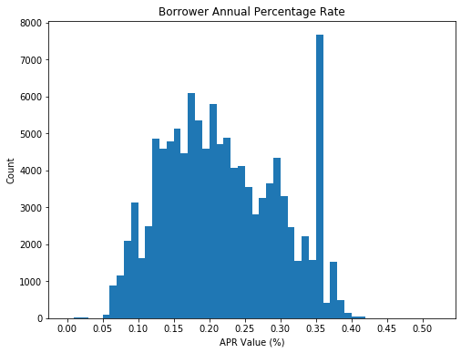

```python
# Plot histogram to have a clear idea of the distribution
bin_edges = np.arange(0, df['BorrowerAPR'].max()+0.01, 0.01)
plt.figure(figsize = [8,6])
plt.hist(data = df, x = 'BorrowerAPR', bins = bin_edges)
plt.title('Borrower Annual Percentage Rate')
plt.xlabel('APR Value (%)')
plt.ylabel('Count')
plt.xticks(np.arange(0, df['BorrowerAPR'].max(), 0.05));
```

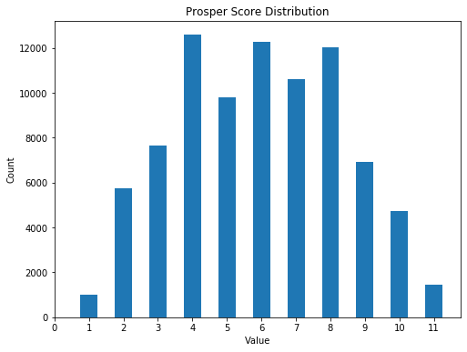

```python
# Plot histogram for the attribute Prosper Score
bin_edges = np.arange(1, df['ProsperScore'].max()+1, 0.5)
plt.figure(figsize = [8,6])
plt.hist(data = df, x = 'ProsperScore', bins = bin_edges, align = 'left')
plt.title('Prosper Score Distribution')
plt.xlabel('Value')
plt.ylabel('Count')
plt.xticks(np.arange(0, df['ProsperScore'].max()+1, 1));
```

> It appears that people with extremely high and extremely low Prosper Score have less chances of getting a loan as most of the borrowers are in the mid range of Prosper Score

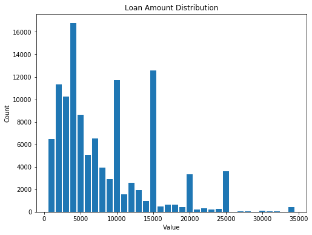

```python
# Histogram for Original Loan Amount
bin_edges = np.arange(1000, df['LoanOriginalAmount'].max()+1000, 1000)
plt.figure(figsize = [8,6])
plt.hist(data = df, x = 'LoanOriginalAmount', bins = bin_edges, align = 'left', rwidth = 0.8)
plt.title('Loan Amount Distribution')
plt.xlabel('Value')
plt.ylabel('Count');
```

> The right skewed behaviour of our histogram suggests that people with lesser amounts of required loan generally get the loan easily.  
> Also, peaks are only observed at rounded values after the amount of 5000.

```python
df['AvailableBankcardCredit'].describe()
```

```
count    106393.000000
mean      11210.225447
std       19818.361309
min           0.000000
25%         880.000000
50%        4100.000000
75%       13180.000000
max      646285.000000
Name: AvailableBankcardCredit, dtype: float64
```

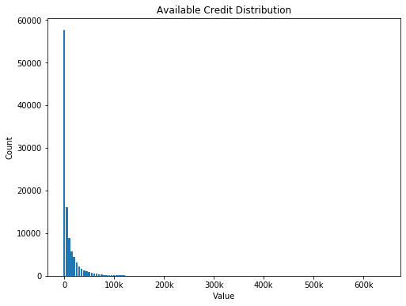

```python
# Histogram for Available Credit for a Borrower
bin_edges = np.arange(0, df['AvailableBankcardCredit'].max(), 5000)
plt.figure(figsize = [8,6])
plt.hist(data = df, x = 'AvailableBankcardCredit', bins = bin_edges, align = 'left', rwidth = 0.8)
plt.title('Available Credit Distribution')
plt.xlabel('Value')
plt.ylabel('Count')
plt.xticks([0, 1e5, 2e5, 3e5, 4e5, 5e5, 6e5], [0, '100k', '200k', '300k', '400k', '500k', '600k']);
```

> Mostly, borrowers have a credit under 100,000.  
> Only very few borrowers have a very high credit limit.

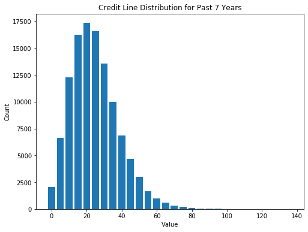

```python
# Histogram for Credit Line
bin_edges = np.arange(0, df['TotalCreditLinespast7years'].max()+5, 5)
plt.figure(figsize = [8,6])
plt.hist(data = df, x = 'TotalCreditLinespast7years', bins = bin_edges, align = 'left', rwidth = 0.8)
plt.title('Credit Line Distribution for Past 7 Years')
plt.xlabel('Value')
plt.ylabel('Count');
```

> The Credit Line for the Borrowers appears to be normally distributed to an extent.  
> Where major borrowers have a credit line in the range 10 to 30.

```python
# Check for the statistics of Monthly Income
df['StatedMonthlyIncome'].describe()
```

```
count    1.139370e+05
mean     5.608026e+03
std      7.478497e+03
min      0.000000e+00
25%      3.200333e+03
50%      4.666667e+03
75%      6.825000e+03
max      1.750003e+06
Name: StatedMonthlyIncome, dtype: float64
```

[figure not shown]

```python
# Plot Histogram for Monthly Income
bin_edges = np.arange(0, df['StatedMonthlyIncome'].max(), 5000)
plt.figure(figsize = [8,6])
plt.hist(data = df, x = 'StatedMonthlyIncome', bins = bin_edges, align = 'left', rwidth = 0.8)
plt.title('Credit Line Distribution for Past 7 Years')
plt.xlabel('Value')
plt.ylabel('Count');
```

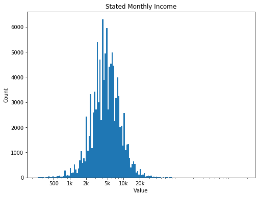

```python
# Logarithmic Scale of Monthly Income
log_binsize = 0.025
bins = 10 ** np.arange(2.4, np.log10(df['StatedMonthlyIncome'].max())+log_binsize, log_binsize)

plt.figure(figsize=[8, 6])
plt.hist(data = df, x = 'StatedMonthlyIncome', bins = bins)
plt.xscale('log')
plt.xticks([500, 1e3, 2e3, 5e3, 1e4, 2e4], [500, '1k', '2k', '5k', '10k', '20k'])
plt.xlabel('Value')
plt.ylabel('Count')
plt.title('Stated Monthly Income')
plt.show()
```

> Since most of the values for monthly income lie under 20k, we plotted a logarithmic plot to check for the values that are in majority.

```python
# Convert ProsperRating and Employment Status into Categorical Datatypes
pros_rate = ['HR','E','D','C','B','A','AA']
pros_classes = pd.api.types.CategoricalDtype(ordered = True, categories = pros_rate)
df['ProsperRating (Alpha)'] = df['ProsperRating (Alpha)'].astype(pros_classes)

status_order = ['Employed','Self-employed','Full-time','Part-time','Retired','Other','Not employed', 'Not available']
status_classes = pd.api.types.CategoricalDtype(ordered = True,
                                    categories = status_order)
df['EmploymentStatus'] = df['EmploymentStatus'].astype(status_classes)
```

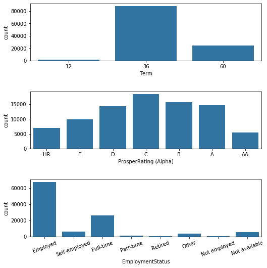

```python
figure, ax = plt.subplots(nrows=3, figsize = [8,8])
base_color = sb.color_palette()[0]
sb.countplot(data = df, x = 'Term', color = base_color, ax = ax[0])
sb.countplot(data = df, x = 'ProsperRating (Alpha)', color = base_color, ax = ax[1])
sb.countplot(data = df, x = 'EmploymentStatus', color = base_color, ax = ax[2]);
plt.xticks(rotation=20)
figure.tight_layout(pad=3.0);
```

> The term for which most borrowers lend is observed to be 36 months.  
> Majorly, the prosper rating of lenders is amongst D, C, B, and A.  
> The borrowers are majorly employed.

### Discuss the distribution(s) of your variable(s) of interest. Were there any unusual points? Did you need to perform any transformations?

> The Variables explored above show the basic distribution in the dataset.  
> It appears that more borrowers have been taking loans for an amount under 15k.  
> Where people generally have a credit limit under 100k.  
> The stated monthly income also seems to lie under 20k for majority of lenders.  
> The dataset has outliers in most variables which might affect our analysis.  
> However, the distribution of our prime factor in consideration, the borrower APR seems multimodel.  
> It does not require any transformations

### Of the features you investigated, were there any unusual distributions? Did you perform any operations on the data to tidy, adjust, or change the form of the data? If so, why did you do this?

> The distributions of Monthly Income and Credit Limit are right skewed. But I don't feel in needs any transformations.  
> We can neglect the outliers and perform further analysis.

## Bivariate Exploration

> Firstly, I would check for the correlation in the factors under consideration using plot matrix and heatmaps.

```python
num_vars = ['BorrowerAPR', 'ProsperScore', 'LoanOriginalAmount', 'AvailableBankcardCredit',
            'TotalCreditLinespast7years', 'StatedMonthlyIncome']
cat_vars = ['Term', 'ProsperRating (Alpha)', 'EmploymentStatus']
```

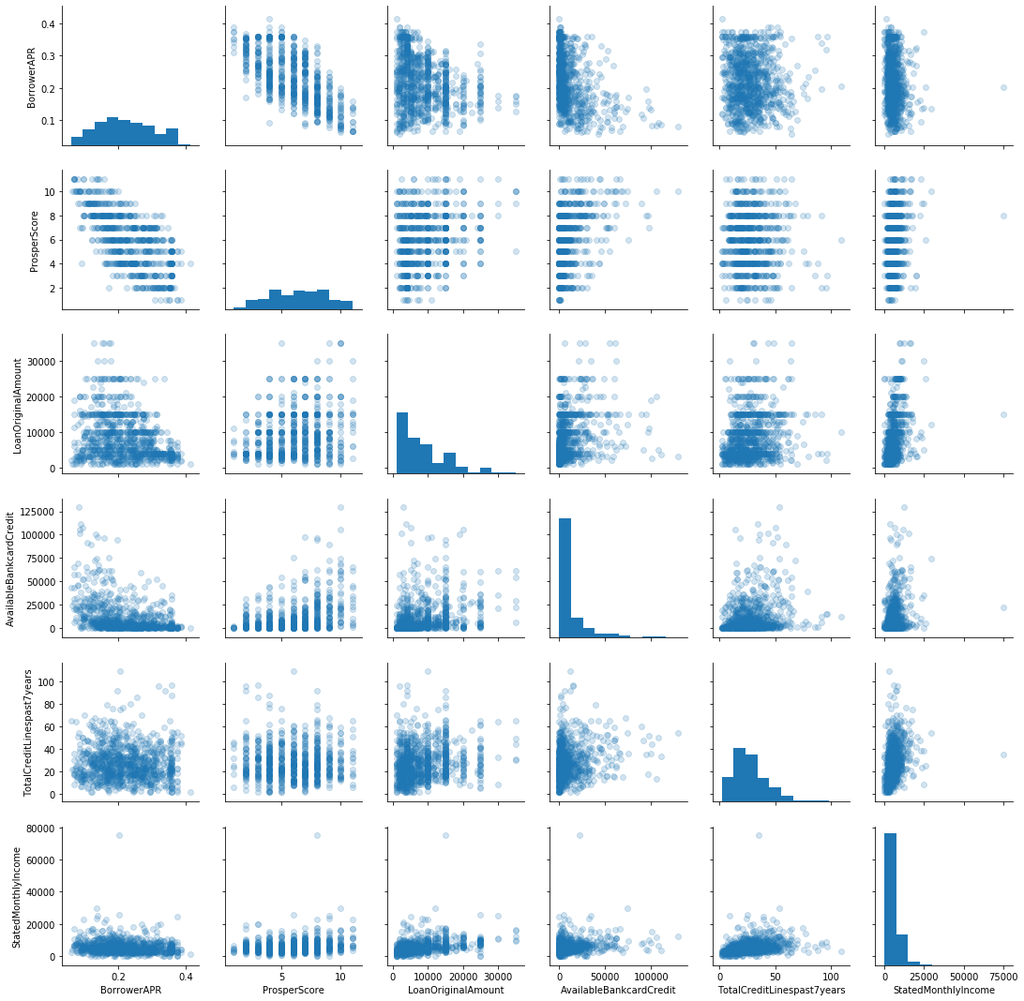

```python
# Plot Matrix for the numeric variables.
df_sample = df.sample(1000) # Taking 1000 entries in order to get a clear plot matrix
g = sb.PairGrid(data = df_sample, vars = num_vars)
g = g.map_diag(plt.hist)
g.map_offdiag(plt.scatter, alpha=1/5);
```

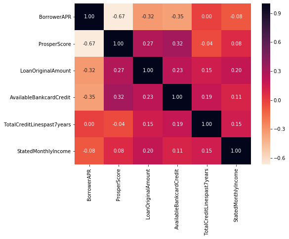

```python
# Heatmap for correlation between numeric variables
plt.figure(figsize = [8,6])
sb.heatmap(df[num_vars].corr(), cmap = 'rocket_r', annot = True, fmt = '.2f');
```

> No pair of entities showed a strong positive correlation.  
> The only strong correlation from the heatmap can be observed between BorrowerAPR and ProsperScore and it is negatively correlated. Which means a borrower with higher prosper score will receive lower APR. Which makes sense.  
> Similarly, a person with higher credit limit or higher loan amount recieved lower APR.

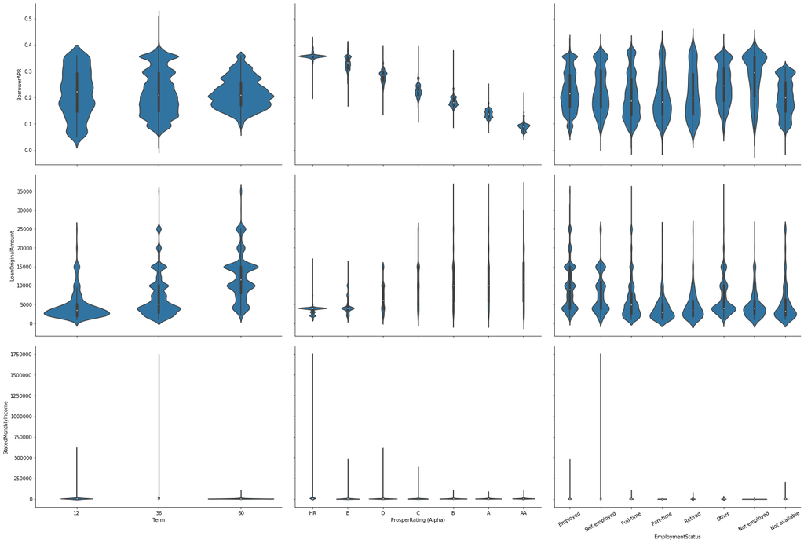

```python
# Plot Matrix for Categorical Variables
plt.figure(figsize = [10, 10])
g = sb.PairGrid(data = df, y_vars = ['BorrowerAPR', 'LoanOriginalAmount', 'StatedMonthlyIncome'],
                x_vars = cat_vars, height = 5, aspect = 1.5)
g.map(sb.violinplot)
plt.xticks(rotation = 30);
```

### Talk about some of the relationships you observed in this part of the investigation. How did the feature(s) of interest vary with other features in the dataset?

> The Heat Map pulled out significant correlations to be established amongst the variables.  
> The BorrowerAPR is negatively correlated to the ProsperScore indicating that a person with a better prosper score will reciever lower APR.  
> Lower amount of loan was associated with higher APR value.  
> Proper Rating suggests that the APR value decreases as the ratings get better. Stated Monthly Income does not seem to have any major effect on the APR value.

### Did you observe any interesting relationships between the other features (not the main feature(s) of interest)?

> The available bank credit was positively correlated with major variables which indicates that more credit relates to higher incomes and loan amounts.  
> The borrowers with better employment status tend to having higher loan amounts.

## Multivariate Exploration

> In this section, I will focus on the BorrowerAPR, Original Loan Amount, Stated Monthly Income and the Categorical Variables (Term and Prosper Rating) to establish a sound relationship between them.

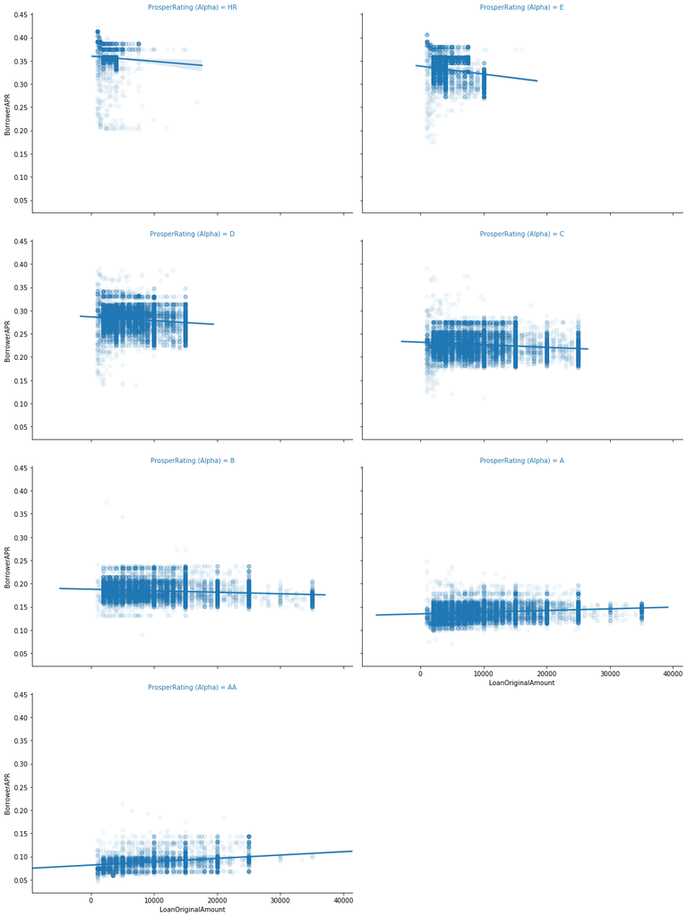

```python
# A scatter plot to check for relationship between Prosper Rating, Loan Amount and Borrower APR
plt.figure(figsize = [6,10])
g=sb.FacetGrid(data=df, aspect=1.5, height=5, col='ProsperRating (Alpha)', col_wrap=2)
g.map(sb.regplot, 'LoanOriginalAmount', 'BorrowerAPR', x_jitter=0.04, scatter_kws={'alpha':0.05});
g.set_titles(color = base_color);
```

> The borrower APR decreases as we move towards better ratings whereas the loan amount tends to increase with better rating.

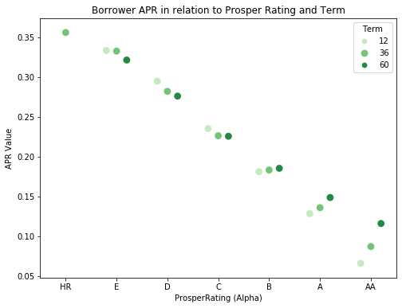

```python
# Check how combined prosper rating and term period affect the APR value
plt.figure(figsize = [8,6])
sb.pointplot(data = df, x = 'ProsperRating (Alpha)', y = 'BorrowerAPR', hue = 'Term',
           palette = 'Greens', linestyles = '', dodge = 0.4, ci=None)
plt.title('Borrower APR in relation to Prosper Rating and Term')
plt.ylabel('APR Value');
```

> Here, we can notice an interestingly varying trend from rating to rating.  
> The APR Value for ratings HR till C decrease with the increase in term whereas beyond B till AA, APR value seems to increase with increase in term.

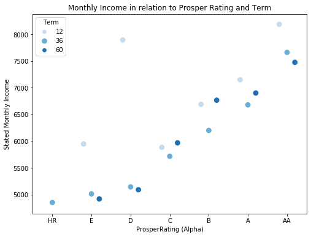

```python
# Check how combined prosper rating and term period affect the Monthly Income
plt.figure(figsize = [8,6])
sb.pointplot(data = df, x = 'ProsperRating (Alpha)', y = 'StatedMonthlyIncome', hue = 'Term',
           palette = 'Blues', linestyles = '', dodge = 0.4, ci = None)
plt.title('Monthly Income in relation to Prosper Rating and Term')
plt.ylabel('Stated Monthly Income');
```

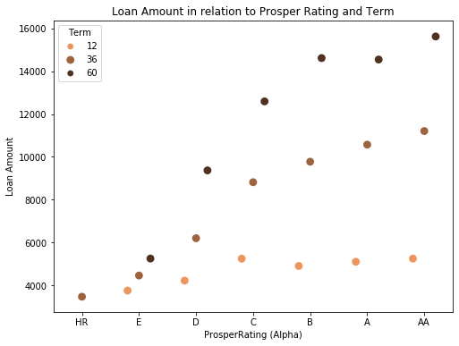

```python
# Check how combined prosper rating and term period affect the Loan Amount
plt.figure(figsize = [8,6])
sb.pointplot(data = df, x = 'ProsperRating (Alpha)', y = 'LoanOriginalAmount', hue = 'Term',
           palette = 'copper_r', linestyles = '', dodge = 0.4, ci = None)
plt.title('Loan Amount in relation to Prosper Rating and Term')
plt.ylabel('Loan Amount');
```

> The loan amount seems to have a positive relation with the term and rating variables combined.  
> As the rating gets better, the loan amount increases with an increase in term.

### Talk about some of the relationships you observed in this part of the investigation. Were there features that strengthened each other in terms of looking at your feature(s) of interest?

> It was observed that the relationship between Borrower APR and Loan Amount turned from being slightly negative to slightly positive with the betterment in Prosper Rating.  
> The loan amounts increased with the increase in term and rating. The increase in loan amounts with increasing term was exponentially higher for better ratings.

### Were there any interesting or surprising interactions between features?

> The most interesting and surprising observation was with the APR value when analyzed with term and rating. It decreased linearly for ratings HR till C with the increase in term and linearly increased with the ratings B till AA.

> At the end of your report, make sure that you export the notebook as an html file from the `File > Download as... > HTML` menu. Make sure you keep track of where the exported file goes, so you can put it in the same folder as this notebook for project submission. Also, make sure you remove all of the quote-formatted guide notes like this one before you finish your report!